# Project1 report

Lin Lin

2023-03-13

## **Project requirements**

### GitHub setup

I created a new account for GitHub and established a repo named STATS220. I edited some project information and personal details such as hobbies and experience to the readme file and demonstrated at least four markdown syntax requirements. I also added some emojis ;D.

[Here is my repo link](https://github.com/Taviralin/Stats-220)

[Here is my website link](https://taviralin.github.io/Stats-220/)

### Project folder

Please see the following screenshots which shows my work and resources:

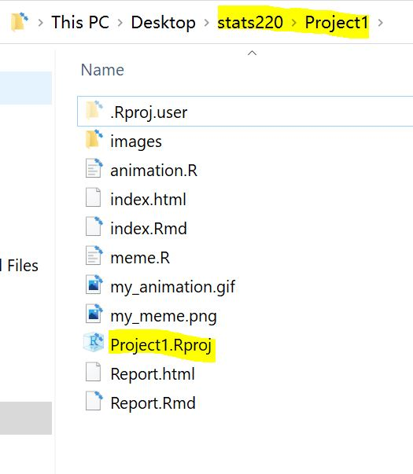

This is Project1 root folder

I put all the images into images folder under project1 folder and frames into frames folder under images folder.

[figure not shown]

This is my images folder

[figure not shown]

This is my frames folder

### Describe creativity

I used some extra images function from Magick to create meme and GIF, for example, I used the “image_border” to add a border to each part of meme and I used “image_morph” function to creates a sequence of n images that gradually morph one image into another.

For index.html, I used some extra function of CSS to optimize the web page. For example, I change the page background by using a image through the function “background-image” and add text decoration by “text-decoration” etc.

I checked few cheat sheets which quite useful to learn something more and selected the ones that I can understand and apply that onto my project.

Here are some links for the cheat sheet:

[This is W3school CSS tutorial](https://www.w3schools.com/css/css_text.asp)

[This is the link of Magick package](https://cran.r-project.org/web/packages/magick/vignettes/intro.html#Animation)

[This is the link of R Markdown cheat sheet](https://www.rstudio.com/wp-content/uploads/2015/02/rmarkdown-cheatsheet.pdf)

## **Learning reflection**

The most important idea that I’ve learnt from module 1 is how to present data on a webpage by using various programming languages. This provided me with a fundamental concept of how the front end worked and how data visualized by creating graphical and literary elements.

Besides that, I’m getting more families with the project workflow instead of doing single questions in an assignment. This is extremely practical because I could start from material collection, analyze, process and display at the end. By following the task instructions, I’m able to think about how the work should be designed and how I can complete it independently.

In the future, I would like to learn more about data mining and data processing, like how to achieve useful raw data and how to clean it by using data technologies. I’m also keen to learn more about R. I’ve done stats201 and learnt a lot of modeling, however most of the code is provided already which I think would be very useful for data analysis.